# Decomposition of Used Car Sales

This is a decomposition analysis of Used Car Dealer Sales ranging from 1992-2025. The data set is not seasonally adjusted and is monthly. (https://fred.stlouisfed.org/series/MRTSSM44112USN)

```
## [1] "MRTSSM44112USN"
```

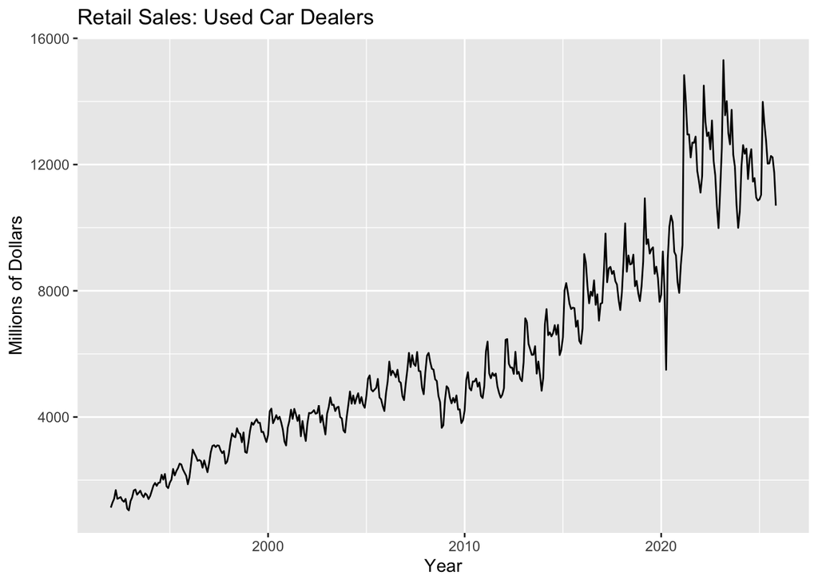

```r
##  ACF and Pattern Indication

### Time Series Plot
autoplot(used_cars) +
  labs(
    title = "Retail Sales: Used Car Dealers",
    y = "Millions of Dollars",
    x = "Year"
  )
```

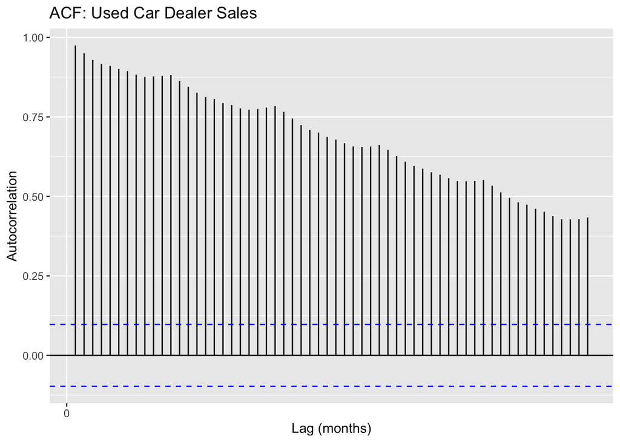

```r
### ACF Plot
acf_values <- acf(used_cars, lag.max = 60, plot = FALSE)

autoplot(acf_values) +
  labs(
    title = "ACF: Used Car Dealer Sales",
    x = "Lag (months)",
    y = "Autocorrelation"
  )
```

The ACF decays slowly and remains highly positive for many lags. The autocorrelations start near 1 and decline steadily rather than dropping off quickly. This indicates a non-stationary series with a strong trend (as seen in the time-series plot). With the persistent upward trend, observations remain highly correlated, which helps to produce a gradual decline in ACF.

There are no sharp isolated spikes at seasonal lags such as 12, 24, and 36. Rather, the autocorrelations remain high across all lags due to the strong trend. This makes seasonal patterns less distinct in the ACF plot.

The series clearly contains both trend and seasonality. The time-series plot shows strong long-run upward movement, and there is a repeating yearly pattern with steady peaks and troughs each year.

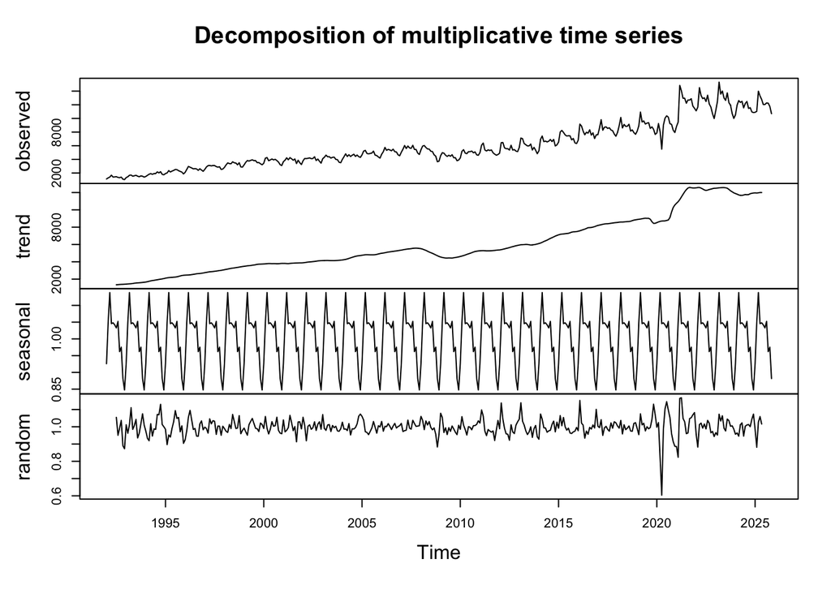

```r
## Classical Decomposition - multiplicative
decomp_classical <- decompose(used_cars, type = "multiplicative")
plot(decomp_classical)
```

```r
trend_component <- decomp_classical$trend
seasonal_indices <- decomp_classical$seasonal
remainder_component <- decomp_classical$random
```

The seasonal indices represent the multiplicative seasonal effect for each month. Values above 1 indicate months where sales are higher than average, and values below 1 indicate months where sales are lower than average. These seasonal indices help to capture predictable yearly patterns.

The most notable irregular shock occurs around 2020. This likely reflects the dip the economy took caused by the COVID-19 pandemic, which reduced economic activity. During this period, supply chains were disrupted, and cars were not a priority purchase, likely leading to a drastic dip in sales.

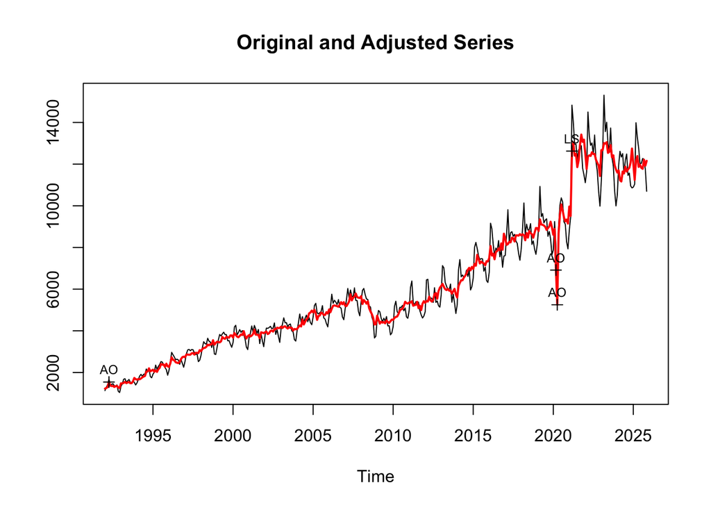

```r
## X-11 Model
x11_model <- seas(used_cars, x11 = "")
plot(x11_model)
```

The seasonal factors from both classical decomposition and the X-11 decomposition are similar. Both identify clear, consistent annual seasonal patterns in used-car dealer sales. This indicates that the underlying seasonal structure of the data is stable across different methods.

The X-11 decomposition appears more stable. Since it uses moving averages and filtering processes designed to handle outliers and irregular shocks, its seasonal factors are smoother and less sensitive to extreme events. The classical decomposition assumes fixed seasonal patterns and ignores volatility. Therefore, the X-11 method provides a more reliable estimate of seasonal fluctuations for this time series.

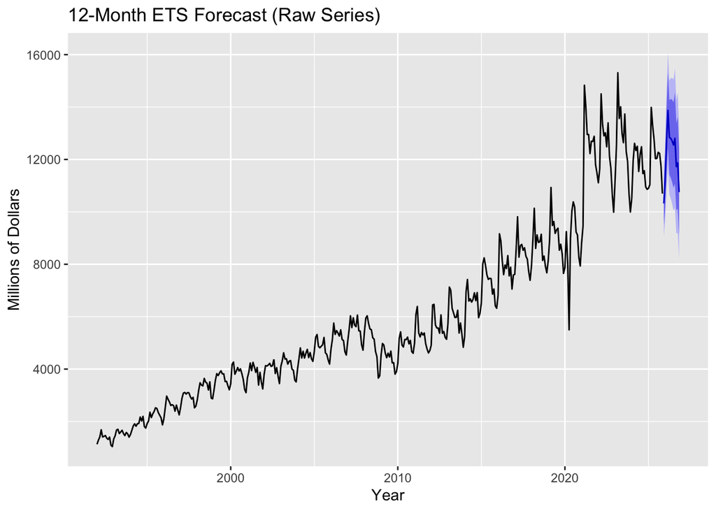

```r
## Forecasting with ETS (12-month Forecast)

### Forecast RAW (unadjusted series)
ets_raw <- ets(used_cars)
fc_raw <- forecast(ets_raw, h = 12)

autoplot(fc_raw) +
  labs(
    title = "12-Month ETS Forecast (Raw Series)",
    y = "Millions of Dollars",
    x = "Year"
  )
```

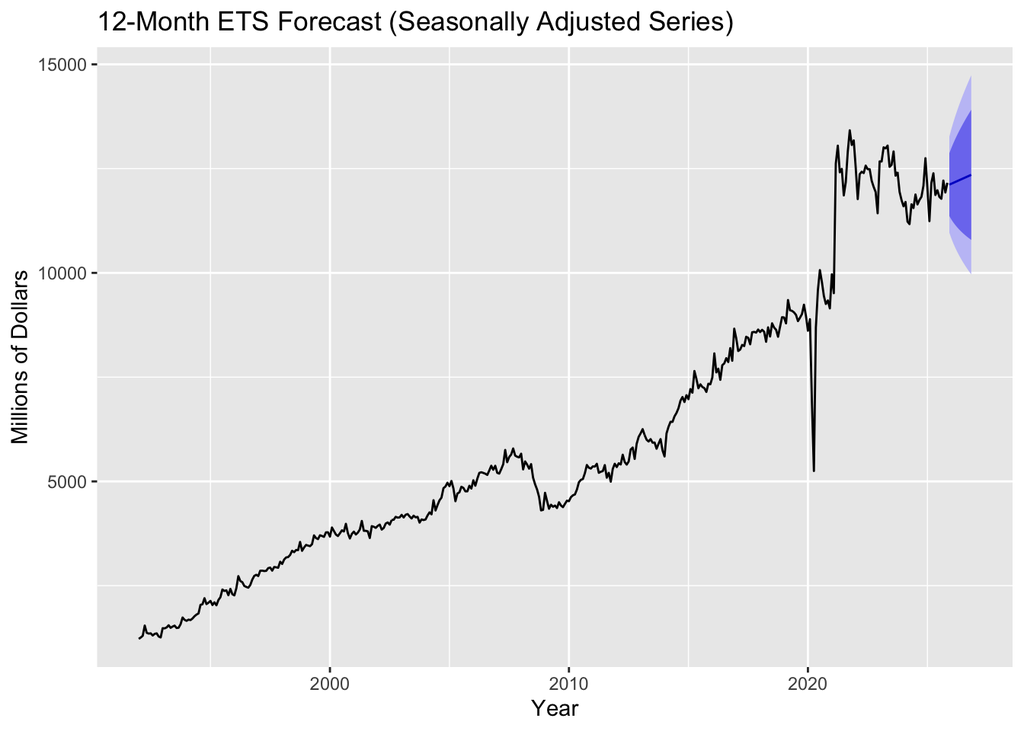

```r
### Forecast SEASONALLY ADJUSTED Series
sa_series <- final(x11_model)
ets_sa <- ets(sa_series)
fc_sa <- forecast(ets_sa, h = 12)

autoplot(fc_sa) +
  labs(
    title = "12-Month ETS Forecast (Seasonally Adjusted Series)",
    y = "Millions of Dollars",
    x = "Year"
  )
```

The raw forecast shows clear seasonal fluctuations, with repeating monthly peaks and troughs. The seasonally adjusted forecast is smoother and reflects an underlying trend without seasonality. Economists often prefer forecasts that are seasonally adjusted because they remove predictable seasonal patterns, providing a clearer view of the economic trend without unnecessary noise and uncertainty. This helps to make interpretations and comparisons easier across time periods.